# DATA607 Project 2

Gabriel Campos

April 21 2021

### UNICEF Dataset

#### Assignment Requirements

The goal of this assignment is to give you practice in preparing different datasets for downstream analysis work. **Your task is to:**

1. Choose any three of the “wide” datasets identified in the Week 6 Discussion items. **(You may use your own dataset; please don’t use my Sample Post dataset, since that was used in your Week 5 assignment!)**
   - For each of the three chosen datasets:
     - Create a .CSV file (or optionally, a MySQL database!) that includes all of the information included in the dataset.
     - *You’re encouraged to use a “wide” structure similar to how the information appears in the discussion item, so that you can practice tidying and transformations as described below.*
     - Read the information from your .CSV file into R, and use `tidyr` and `dplyr` as needed to tidy and transform your data. [Most of your grade will be based on this step!]
     - Perform the analysis requested in the **discussion item.** $\ \$ *note$^1$*
     - Your code should be in an R Markdown file, posted to [rpubs.com](https://rpubs.com/%5D%20web%20page), and should include narrative descriptions of your data cleanup work, analysis, and conclusions.
2. Please include in your homework submission, for each of the three chosen datasets:
   - The URL to the .Rmd file in your GitHub repository, and
   - The URL for your [rpubs.com](https://rpubs.com/%5D%20web%20page)

#### Notes

1. Notes from the bottom of the .csv were excluded. Main data was selected between rows 5 to 222.

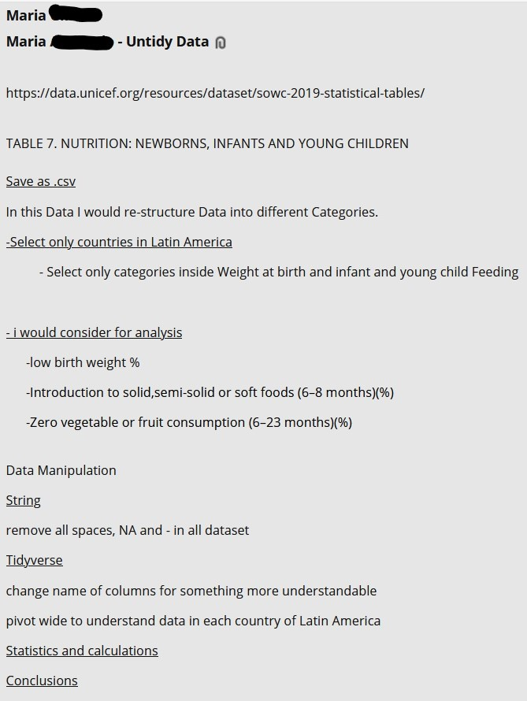

2. `NA` and `?` were deliberately set to NA
3. encoding set to *latin1* to account for accents, in country naming convention
4. `NA` columns are in odd number columns, select utilizing regex.
5. Columns with a `%` indicator will be divided by 100 and `(thousands)` multiplied by 1000 accordingly
6. `NA`, `-`, `x` and `?` were deliberately set to NA
7. `NA` columns are in odd number columns, select utilizing regex and specifying exception column 46.
8. `|` was added as a delimiter to later seperate gender.
9. `cbind` was not used to bind to `df_Out_of_School` at this point, because the number of rows do not match.
10. Original data was in the format `.xlsx` and converted to `.csv`. A formatting error with blank space `U+0096` occurred creating an issue upon import. `.csv` was opened with a notepad, then copied from `Nutrition A.csv` to `Nutrition A 1.csv` correcting the error and allowing the import to occur with the transformation of unnecessary characters into `NA`
11. `NA`, `-`, `x`, and `?` were deliberately set to NA
12. `NA` columns are in odd number columns, select utilizing regex.

### Datasets

#### Nutrition

##### Import Data

`UTF-8` Character error resolved before import. *note$^{10}$* Data is imported from the .csv `Nutrition A 1.csv` from my [github Project 2 folder](https://github.com/gcampos100/DATA607Spring2021/tree/main/Projects/Project%202) using the function `read_csv` from the `readr` package.

```r
df_Nutrition <-
  read_csv(csv_Nutrition_A,
                col_names = FALSE,
          na = c("NA","?","–","x"," ",""),
          skip = 7,
          n_max = 202,
          locale = readr::locale(encoding = "latin1"),
          )
```

*note$^{11}$*

```r
df_Nutrition <-
  df_Nutrition %>%
  select (everything(), -matches("[3579]$"),-matches("[12][13579]$"))
```

*note$^{12}$*

**The Headers were not workable as a direct import from the csv, due to several columns having multi-headers as shown below**

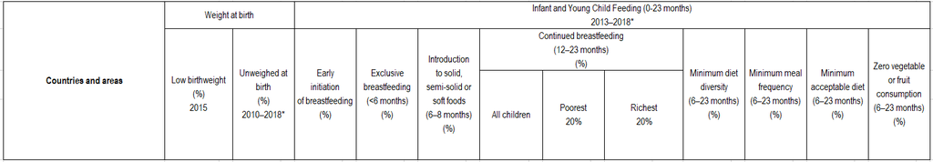

```r
colnames(df_Nutrition)<- colnames_df_Nutrition
```

Column Names and Type

| Countries and areas | character |
| --- | --- |
| Weight at birth Low birthweight (%) 2015 | numeric |
| Weight at birth Unweighed at birth (%) 2010–2018* | numeric |
| Early initiation of breastfeeding (%) | numeric |
| Exclusive breastfeeding (<6 months)(%) | character |
| Introduction to solid, semi-solid or soft foods (6–8 months) (%) | numeric |
| Continued breastfeeding (12–23 months) (%) All children | numeric |
| Continued breastfeeding (12–23 months) (%) Poorest 20% | numeric |
| Continued breastfeeding (12–23 months) (%) richest 20% | numeric |
| Minimum diet diversity (6–23 months) (%) | numeric |
| Minimum meal frequency (6–23 months) (%) | numeric |
| Minimum acceptable diet (6–23 months) (%) | numeric |
| Zero vegetable or fruit consumption (6–23 months) (%) | numeric |

Manual column names were used in place of the **.csv multi-headers**. Names are basically a concatenation of the *Main Header* and *Sub Headers* whenever applicable.

##### Manipulating Imported Data

*note$^{1}$*

Paraphrased Instructions, based on post, not in the same order, are as follows:

- Remove all `blank spaces` and `NA`’s from the data set. **(PARTIALLY COMPLETE ON IMPORT)**
- Select for Analysis:
  - Latin American Countries
  - Low birth weight percentage
  - Introduction to solid, semi-solid or soft foods (6-8 months) (%)
  - Zero vegetable or fruit consumption (6-23 months) (%)
- Rename columns
- Pivot wide
- Calculate stats

According to [WorldPopulationReview.com](https://worldpopulationreview.com/country-rankings/latin-american-countries) Latin countries consist of.

- Argentina
- Bolivia
- Brazil
- Chile
- Colombia
- Costa Rica
- Cuba
- The Dominican Republic
- Ecuador
- El Salvador
- Guatemala
- Honduras
- Mexico
- Nicaragua
- Panama
- Paraguay
- Peru
- Puerto Rico
- Uruguay
- Venezuela

Which is stored in the string `str_latin_countries` to filter with.

```r
str_latin_countries<-"Argentina|Bolivia|Brazil|Chile|
Colombia|Costa Rica|Cuba|Dominican Republic|Ecuador|
El Salvador|Guatemala|Honduras|Mexico|Nicaragua|Panama|
Paraguay|Peru|Puerto Rico|Uruguay|Venezuela"
```

The required columns and rows are selected using pipe `%>%`, `filter()`, and `select()` functions.

Using `str_latin_countries`, the correct countries are specified.

Renaming takes place in accordance with instrucitons.

The resulting in the table is below.

```r
df_Nutrition_Analysis<-df_Nutrition%>%
  filter(str_detect(`Countries and areas`, str_latin_countries))%>%
  select(1,2, 6,13) %>%
  rename("Countries" = `Countries and areas`,
         "Low Birth Weight" = `Weight at birth Low birthweight (%) 2015`,
         "Intro to Solids"=`Introduction to solid, semi-solid or soft foods (6–8 months) (%)`,
         "Zero (Vegetables|Fruits)"=`Zero vegetable or fruit consumption (6–23 months) (%)`)
```

```r
kbl(df_Nutrition_Analysis)
```

| Countries | Low Birth Weight | Intro to Solids | Zero (Vegetables\|Fruits) |
| --- | --- | --- | --- |
| Argentina | 7 | 97 | NA |
| Bolivia (Plurinational State of) | 7 | 81 | 20 |
| Brazil | 8 | 94 | NA |
| Chile | 6 | NA | NA |
| Costa Rica | 7 | 90 | NA |
| Cuba | 5 | 91 | 27 |
| Dominican Republic | 11 | 81 | 35 |
| Ecuador | 11 | 74 | NA |
| Guatemala | 11 | 80 | 27 |
| Honduras | 11 | 86 | 36 |
| Mexico | 8 | 82 | 18 |
| Nicaragua | 11 | 89 | NA |
| Panama | 10 | 78 | NA |
| Peru | 9 | 95 | 7 |
| Uruguay | 8 | NA | NA |
| Venezuela (Bolivarian Republic of) | 9 | NA | NA |

removing `NA` values reduces the `rows` from 16 to 7.

```r
df_Nutrition_Analysis<-na.omit(df_Nutrition_Analysis)
```

| Countries | Low Birth Weight | Intro to Solids | Zero (Vegetables\|Fruits) |
| --- | --- | --- | --- |
| Bolivia (Plurinational State of) | 7 | 81 | 20 |
| Cuba | 5 | 91 | 27 |
| Dominican Republic | 11 | 81 | 35 |
| Guatemala | 11 | 80 | 27 |
| Honduras | 11 | 86 | 36 |
| Mexico | 8 | 82 | 18 |
| Peru | 9 | 95 | 7 |

##### Analysis

Use of `pivot_longer` and `pivot_wider` did very little to enhance understanding of the data. Instead a linear model that shows a positive predictor in `Low Birth weight` from the `Zero (Vegetable | Fruit)` variable and a negative one with `Intro to Solids`.

```r
df_Nutrition_Analysis %>%
pivot_wider(`Low Birth Weight`)
```

```
## # A tibble: 5 x 1
##   `Low Birth Weight`
##                <dbl>
## 1                  7
## 2                  5
## 3                 11
## 4                  8
## 5                  9
```

```r
df_Nutrition_Analysis %>%
pivot_longer(`Zero (Vegetables|Fruits)`)
```

```
## # A tibble: 7 x 5
##   Countries             `Low Birth Weight` `Intro to Solid~ name           value
##   <chr>                              <dbl>            <dbl> <chr>          <dbl>
## 1 Bolivia (Plurination~                  7               81 Zero (Vegetab~    20
## 2 Cuba                                   5               91 Zero (Vegetab~    27
## 3 Dominican Republic                    11               81 Zero (Vegetab~    35
## 4 Guatemala                             11               80 Zero (Vegetab~    27
## 5 Honduras                              11               86 Zero (Vegetab~    36
## 6 Mexico                                 8               82 Zero (Vegetab~    18
## 7 Peru                                   9               95 Zero (Vegetab~     7
```

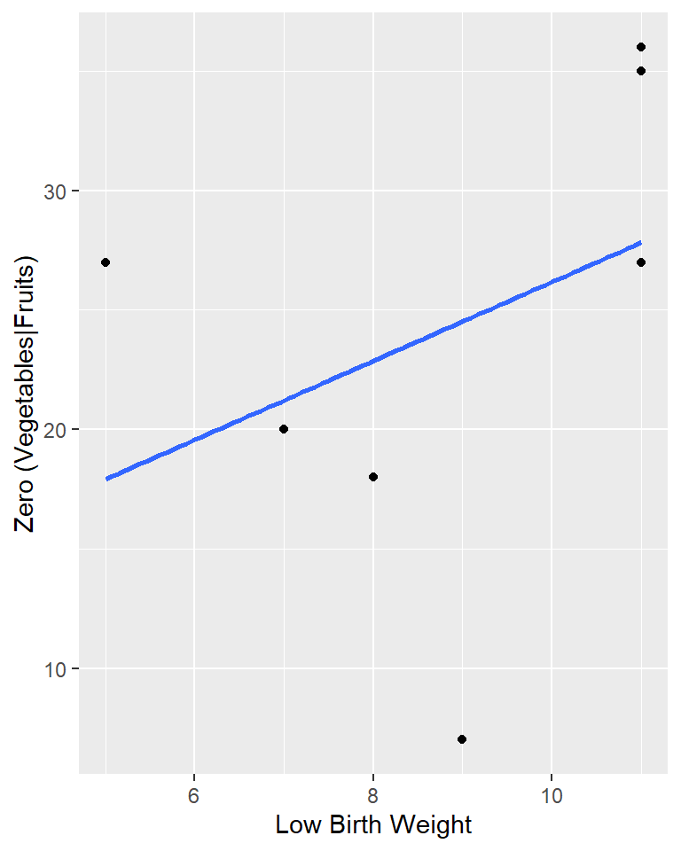

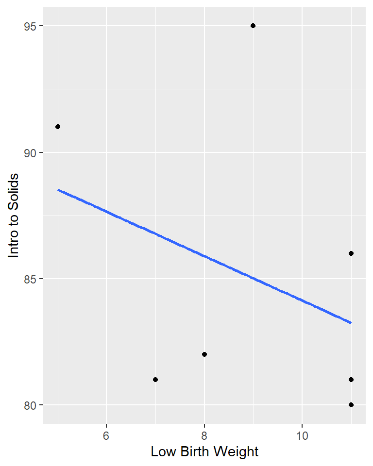

#### Child Mortality

##### Import Data

Data is imported from the .csv’s `Child Mortality.csv` from my [github Project 2 folder](https://github.com/gcampos100/DATA607Spring2021/tree/main/Projects/Project%202) using the function `read_csv` from the `readr` package.

```r
df_Child_Mortality <-
  read_csv(csv_Child_Mortality,
                 col_names = FALSE,
                 na = c("NA","?"),
                         skip = 5,
                       n_max = 202,
                 locale = readr::locale(encoding = "latin1"))
```

*note$^{2\&3}$*

**The Headers were not workable as a direct import from the csv, due to several columns having multi-headers as shown below**

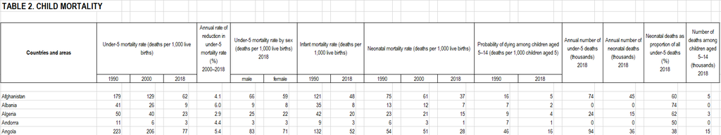

Names were stored to the variable `colname_Child_Mortality` and applied to the data frame. Columns comprised entirely of `NA` values, are removed as well.

```r
df_Child_Mortality <-
  df_Child_Mortality %>%
  select (everything(),
          -matches("[3579]$"),
          -matches("[123][13579]$"))
```

*notes$^{4}$*

```r
colnames(df_Child_Mortality)<- colnames_Child_Mortality
```

Column Names and Type

| Countries and areas | character |
| --- | --- |
| Under-5 mortality rate (deaths per 1,000 live births) 1990 | numeric |
| Under-5 mortality rate (deaths per 1,000 live births) 2000 | numeric |
| Under-5 mortality rate (deaths per 1,000 live births) 2018 | numeric |
| Annual rate of reduction in under-5 mortality rate (%) | numeric |
| Under-5 mortality rate by sex (deaths per 1,000 live births) 2018 (male) | numeric |
| Under-5 mortality rate by sex (deaths per 1,000 live births) 2018 (female) | numeric |
| Infant mortality rate (deaths per 1,000 live births) 1990 | numeric |
| Infant mortality rate (deaths per 1,000 live births) 2018 | numeric |
| Neonatal mortality rate (deaths per 1,000 live births) 1990 | numeric |
| Neonatal mortality rate (deaths per 1,000 live births) 2000 | numeric |
| Neonatal mortality rate (deaths per 1,000 live births) 2018 | numeric |
| Probability of dying among children aged 5–14 (deaths per 1,000 children aged 5) 1990 | numeric |
| Probability of dying among children aged 5–14 (deaths per 1,000 children aged 5) 2018 | numeric |
| Annual number of under-5 deaths (thousands) 2018 | numeric |
| Annual number of neonatal deaths (thousands) 2018 | numeric |
| Neonatal deaths as proportion of all under-5 deaths (%) | numeric |
| Number of deaths among children aged 5–14 (thousands)2018 | numeric |

Manual column names were used in place of the **.csv multi-headers**. Names are basically a concatenation of the *Main Header* and *Sub Headers* whenever applicable.

##### Manipulating Imported Data

The existing data frame `df_Child_Mortality` is a strong representation of the data stored, **as is**, on the *.csv*. Many values in the data set are specified in the header as **(deaths per 1,000 lives births)** however.

| Under-5 mortality rate (deaths per 1,000 live births) 1990 | Under-5 mortality rate (deaths per 1,000 live births) 2000 | Under-5 mortality rate (deaths per 1,000 live births) 2018 | Under-5 mortality rate by sex (deaths per 1,000 live births) 2018 (male) | Under-5 mortality rate by sex (deaths per 1,000 live births) 2018 (female) | Infant mortality rate (deaths per 1,000 live births) 1990 | Infant mortality rate (deaths per 1,000 live births) 2018 | Neonatal mortality rate (deaths per 1,000 live births) 1990 | Neonatal mortality rate (deaths per 1,000 live births) 2000 | Neonatal mortality rate (deaths per 1,000 live births) 2018 | Probability of dying among children aged 5–14 (deaths per 1,000 children aged 5) 1990 | Probability of dying among children aged 5–14 (deaths per 1,000 children aged 5) 2018 |
| --- | --- | --- | --- | --- | --- | --- | --- | --- | --- | --- | --- |
| 179 | 129 | 62 | 66 | 59 | 121 | 48 | 75 | 61 | 37 | 16 | 5 |
| 41 | 26 | 9 | 9 | 8 | 35 | 8 | 13 | 12 | 7 | 7 | 2 |
| 50 | 40 | 23 | 25 | 22 | 42 | 20 | 23 | 21 | 15 | 9 | 4 |
| 11 | 6 | 3 | 3 | 3 | 9 | 3 | 6 | 3 | 1 | 7 | 1 |
| 223 | 206 | 77 | 83 | 71 | 132 | 52 | 54 | 51 | 28 | 46 | 16 |
| NA | NA | NA | NA | NA | NA | NA | NA | NA | NA | NA | NA |
| 28 | 16 | 6 | 7 | 6 | 24 | 5 | 15 | 9 | 3 | 5 | 1 |
| 29 | 20 | 10 | 11 | 9 | 25 | 9 | 15 | 11 | 6 | 3 | 2 |
| 49 | 31 | 12 | 14 | 11 | 42 | 11 | 23 | 16 | 6 | 3 | 2 |
| 9 | 6 | 4 | 4 | 3 | 8 | 3 | 5 | 4 | 2 | 2 | 1 |

[output cut: 192 more lines]

In order to simplify the values and names accordingly, I divide the values in those columns by 1000 and remove the comments from each column name.

```r
#copy integer valued table to address formatting issues with kableExtra:: and reactable::
df_int_Child_Mortality<-
  df_Child_Mortality
#located index of 1,000 columns for formatting with kableExtra:: and reactable::
column_1000_index<-
  grep("1,000 ",colnames(df_int_Child_Mortality))
#Divide values by 1000
df_Child_Mortality<-
  df_Child_Mortality %>%
  mutate_at( vars( matches("\\(deaths per 1,000 live births)")) ,
             funs(./1000))
```

```r
#rename columns
colnames(df_Child_Mortality)<-
  str_replace_all(colnames(df_Child_Mortality),
    pattern = "\\(deaths per 1,000 live births\\)|\\(deaths per 1,000 children aged 5\\)",
                           replacement = "")
```

```r
#change type back to numeric after renaming columns converted it into `num`
df_Child_Mortality[] <-
  lapply(df_Child_Mortality,
         function(x) {
    if(is.factor(x)) round(as.numeric(as.character(x)),3) else x
})
```

[output not shown]

The values inside the columns with `%` and `(thousands)` indicators will also be modified to reflect the exact numeric value. *note$^5$*

| Annual rate of reduction in under-5 mortality rate (%) | Annual number of under-5 deaths (thousands) 2018 | Annual number of neonatal deaths (thousands) 2018 | Neonatal deaths as proportion of all under-5 deaths (%) | Number of deaths among children aged 5–14 (thousands)2018 |
| --- | --- | --- | --- | --- |
| 4.1 | 74 | 45 | 60 | 5 |
| 6.0 | 0 | 0 | 74 | 0 |
| 2.9 | 24 | 15 | 62 | 3 |
| 4.4 | 0 | 0 | 50 | 0 |

```r
#Divides % column values by 100
df_Child_Mortality<-
  df_Child_Mortality %>%
  mutate_at( vars( matches("\\%")) ,
             funs(./100))

#Multiplies "(thousands)" column values by 1000
df_Child_Mortality<-
  df_Child_Mortality %>%
  mutate_at( vars( matches("thousands")) ,
             funs(.*1000))
```

```r
#rename columns
colnames(df_Child_Mortality)<-
  stringr::str_replace_all(colnames(df_Child_Mortality),
                           "\\(\\%\\)|\\(thousands\\)",
                           "")
```

The final table before calculating for analysis is below.

| Countries and areas | Under-5 mortality rate 1990 | Under-5 mortality rate 2000 | Under-5 mortality rate 2018 | Annual rate of reduction in under-5 mortality rate | Under-5 mortality rate by sex 2018 (male) | Under-5 mortality rate by sex 2018 (female) | Infant mortality rate 1990 | Infant mortality rate 2018 | Neonatal mortality rate 1990 | Neonatal mortality rate 2000 | Neonatal mortality rate 2018 | Probability of dying among children aged 5–14 1990 | Probability of dying among children aged 5–14 2018 | Annual number of under-5 deaths 2018 | Annual number of neonatal deaths 2018 | Neonatal deaths as proportion of all under-5 deaths | Number of deaths among children aged 5–14 2018 |
| --- | --- | --- | --- | --- | --- | --- | --- | --- | --- | --- | --- | --- | --- | --- | --- | --- | --- |
| Afghanistan | 0.179 | 0.129 | 0.062 | 0.041 | 0.066 | 0.059 | 0.121 | 0.048 | 0.075 | 0.061 | 0.037 | 16 | 5 | 74000 | 45000 | 0.6 | 5000 |
| Albania | 0.041 | 0.026 | 0.009 | 0.06 | 0.009 | 0.008 | 0.035 | 0.008 | 0.013 | 0.012 | 0.007 | 7 | 2 | 0 | 0 | 0.74 | 0 |
| Algeria | 0.05 | 0.04 | 0.023 | 0.029 | 0.025 | 0.022 | 0.042 | 0.02 | 0.023 | 0.021 | 0.015 | 9 | 4 | 24000 | 15000 | 0.62 | 3000 |
| Andorra | 0.011 | 0.006 | 0.003 | 0.044 | 0.003 | 0.003 | 0.009 | 0.003 | 0.006 | 0.003 | 0.001 | 7 | 1 | 0 | 0 | 0.5 | 0 |
| Angola | 0.223 | 0.206 | 0.077 | 0.054 | 0.083 | 0.071 | 0.132 | 0.052 | 0.054 | 0.051 | 0.028 | 46 | 16 | 94000 | 36000 | 0.38 | 15000 |
| Anguilla | NA | NA | NA | NA | NA | NA | NA | NA | NA | NA | NA | NA | NA | NA | NA | NA | NA |
| Antigua and Barbuda | 0.028 | 0.016 | 0.006 | 0.05 | 0.007 | 0.006 | 0.024 | 0.005 | 0.015 | 0.009 | 0.003 | 5 | 1 | 0 | 0 | 0.5 | 0 |
| Argentina | 0.029 | 0.02 | 0.01 | 0.038 | 0.011 | 0.009 | 0.025 | 0.009 | 0.015 | 0.011 | 0.006 | 3 | 2 | 8000 | 5000 | 0.64 | 2000 |
| Armenia | 0.049 | 0.031 | 0.012 | 0.051 | 0.014 | 0.011 | 0.042 | 0.011 | 0.023 | 0.016 | 0.006 | 3 | 2 | 1000 | 0 | 0.52 | 0 |
| Australia | 0.009 | 0.006 | 0.004 | 0.029 | 0.004 | 0.003 | 0.008 | 0.003 | 0.005 | 0.004 | 0.002 | 2 | 1 | 1000 | 1000 | 0.62 | 0 |

[output cut: 192 more lines]

##### Analysis

I noted that the data set did not focus on Central or South America specifically. Mortality in these relationships are correlation just based on the label names. If a mortality rate in any aspect increases, so would the total mortality rate by country region etcetera. The analysis here is just to note the average by these two regions, not specifically accounted for in the original data set.

The calculation for the regions male & female mortality count is:

$\sum_{i=first}^{last}(Rate\times Annual)_i$

Where:

$first$ & $last$ refers to the country selected.

$Rate$ is the specified mortality rate *(male/female)*

and the calculation for the Annual number of deaths is just $\sum_{Annual\ per\ country}$

```r
df_CAmerica <-
  c("Belize","Costa Rica","El Salvador",
     "Guatemala","Honduras","Nicaragua","Panama")

df_CAmerica <-
  df_Child_Mortality %>%
  filter(`Countries and areas` %in% c(df_CAmerica)) %>%
    select(`Countries and areas`,
           `Under-5 mortality rate by sex  2018 (male)`,
           `Under-5 mortality rate by sex  2018 (female)`,
           `Annual number of under-5 deaths  2018`)

df_CAmerica<-
  df_CAmerica %>%
    rbind(c("Total Central America",
          sum(df_CAmerica$`Under-5 mortality rate by sex  2018 (male)`*
                df_CAmerica$`Annual number of under-5 deaths  2018`),
          sum(df_CAmerica$`Under-5 mortality rate by sex  2018 (female)`*
                df_CAmerica$`Annual number of under-5 deaths  2018`),
          sum(df_CAmerica$`Annual number of under-5 deaths  2018`)))
```

```r
df_SAmerica <-
  c("Argentina","Bolivia","Brazil","Chile","Colombia",
    "Ecuador","Guyana","Paraguay","Peru","Suriname",
    "Uruguay","Venezuela")

df_SAmerica<-
  df_Child_Mortality %>%
  filter(`Countries and areas` %in% c(df_SAmerica)) %>%
    select(`Countries and areas`,
           `Under-5 mortality rate by sex  2018 (male)`,
           `Under-5 mortality rate by sex  2018 (female)`,
           `Annual number of under-5 deaths  2018`)

df_SAmerica<-
  df_SAmerica %>%
    rbind(c("Total South America",
          sum(df_SAmerica$`Under-5 mortality rate by sex  2018 (male)`*
                df_SAmerica$`Annual number of under-5 deaths  2018`),
          sum(df_SAmerica$`Under-5 mortality rate by sex  2018 (female)`*
                df_SAmerica$`Annual number of under-5 deaths  2018`),
          sum(df_SAmerica$`Annual number of under-5 deaths  2018`)))
```

| Central America Countries | Central America Male | Central America Female | Central America Annual |
| --- | --- | --- | --- |
| Belize | 0.014 | 0.012 | 0 |
| Costa Rica | 0.01 | 0.008 | 1000 |
| El Salvador | 0.015 | 0.012 | 2000 |
| Guatemala | 0.029 | 0.023 | 11000 |
| Honduras | 0.019 | 0.016 | 4000 |
| Nicaragua | 0.02 | 0.016 | 2000 |
| Panama | 0.017 | 0.014 | 1000 |
| Total Central America | 492 | 395 | 21000 |

| South America Countries | South America Male | South America Female | South America Annual |
| --- | --- | --- | --- |
| Argentina | 0.011 | 0.009 | 8000 |
| Brazil | 0.016 | 0.013 | 42000 |
| Chile | 0.008 | 0.007 | 2000 |
| Colombia | 0.016 | 0.013 | 10000 |
| Ecuador | 0.016 | 0.013 | 5000 |
| Guyana | 0.034 | 0.026 | 0 |
| Paraguay | 0.022 | 0.018 | 3000 |
| Peru | 0.016 | 0.013 | 8000 |
| Suriname | 0.021 | 0.017 | 0 |
| Uruguay | 0.008 | 0.007 | 0 |
| Total South America | 1210 | 985 | 78000 |

The data was reformatted during the manipulation. Utilizing pipe and cbind, it is recreated with the necessary values being numeric. The combined data frame is `df_S_C_America`

A visual representation of the total Annual death rate for those under 5 years old is highlighted in the plot below. Noteablly *Brazil* has a higher count then Central America as a whole. Brazil is a large country, however those numbers are still very high.

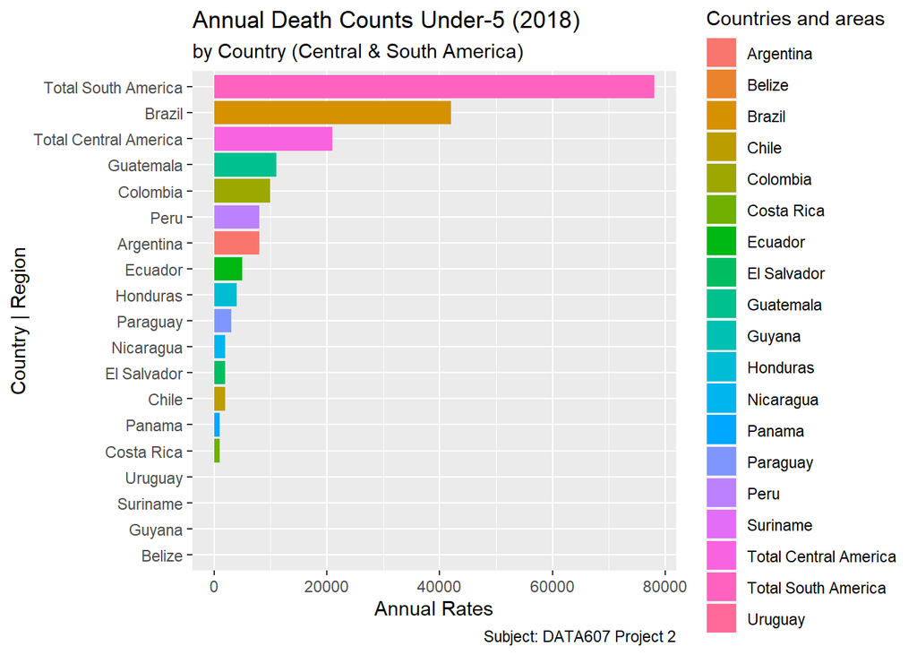

Unsurprisingly South America has a higher count for both genders, I would attribute this to the larger country size and high count of *Brazil* which resides in South America.

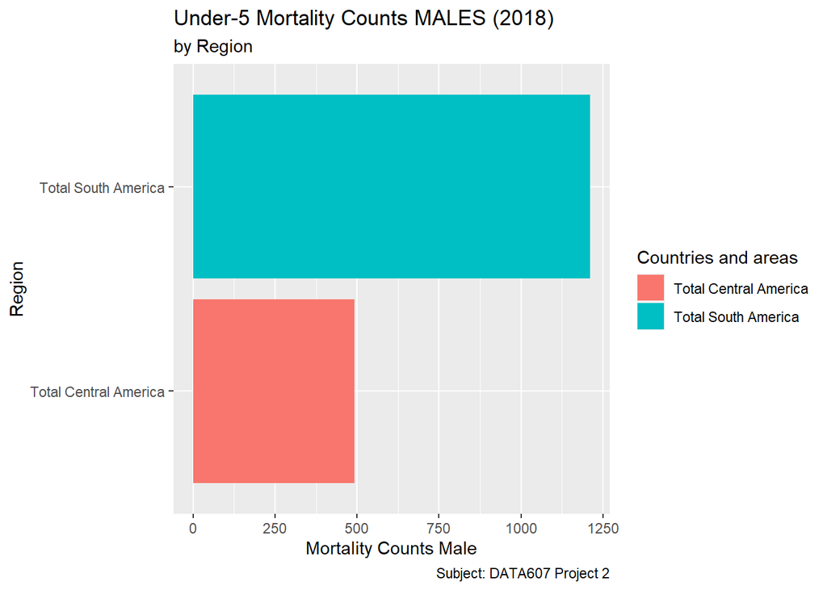

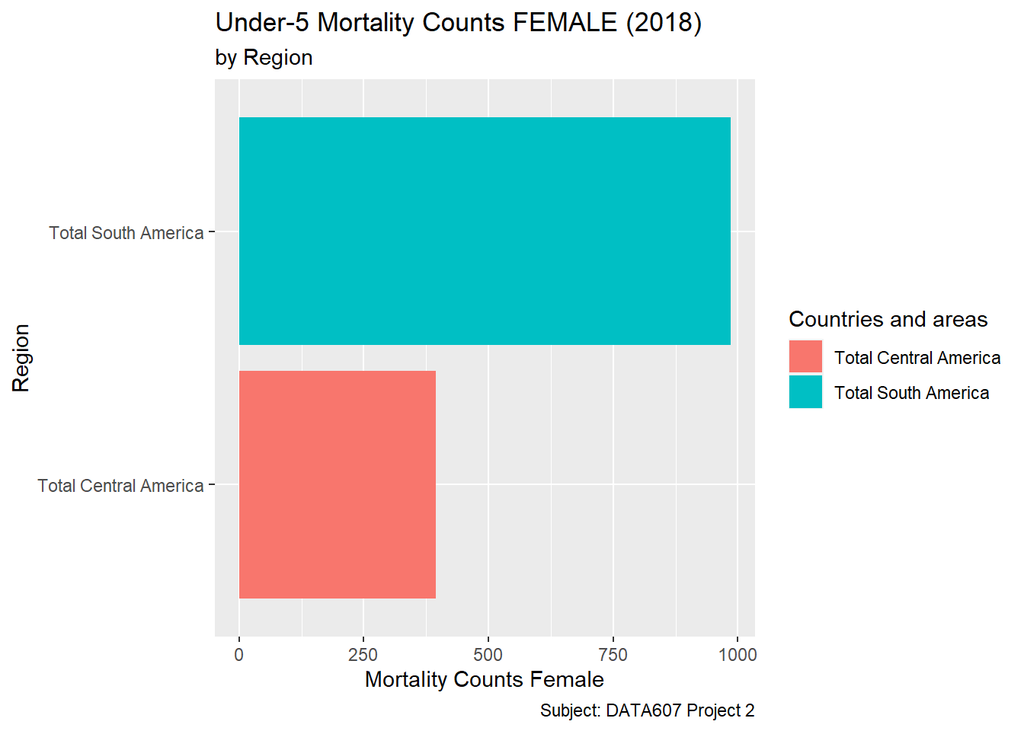

#### Education

##### Import Data

Data is imported from the .csv’s `Education.csv` from my [github Project 2 folder](https://github.com/gcampos100/DATA607Spring2021/tree/main/Projects/Project%202) using the function `read_csv` from the `readr` package.

```r
df_Education <-
  read_csv(csv_Child_Education,
                col_names = FALSE,
          na = c("NA","?","-","x"),
          skip = 7,
          n_max = 202,
          locale = readr::locale(encoding = "latin1"))
```

**The Headers were again not workable as a direct import from the csv, due to several columns having multi-headers, sum as many as 4 (as shown below). All data is between the time range 2010-2018**

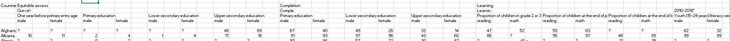

Names were stored to the variable `colname_Education` and applied to the data frame. Columns comprised entirely of `NA` values, are removed as well.

```r
df_Education <-
  df_Education %>% select (everything(), -matches("[3579]$"),-matches("[1234][13579]$"),-46)
```

```r
colnames(df_Education)<-
  colnames_Education
```

Column Names and Type

| Countries and areas | character |
| --- | --- |
| Out of School rate - One Year before primary entry age \| male | numeric |
| Out of School rate -One Year before primary entry age \| female | numeric |
| Out of School rate -Primary Education \| male | numeric |
| Out of School rate -Primary Education \| female | numeric |
| Out of School rate -Lower secondary education \| male | numeric |
| Out of School rate -Lower secondary education \| female | numeric |
| Out of School rate -Upper secondary education \| male | numeric |
| Out of School rate -Upper secondary education \| female | numeric |
| Completion Rate - Primary education \| male | numeric |
| Completion Rate - Primary education \| female | numeric |
| Completion Rate - Lower secondary education \| male | numeric |
| Completion Rate - Lower secondary education \| female | numeric |
| Completion Rate - Upper secondary education \| male | numeric |
| Completion Rate - Upper secondary education \| female | numeric |
| Proportion of children in grade 2 or 3 achieving minimum proficiency level \| reading | numeric |
| Proportion of children in grade 2 or 3 achieving minimum proficiency level \| math | numeric |
| Proportion of children at the end of primary achieving minimum proficiency level \| reading | numeric |
| Proportion of children at the end of primary achieving minimum proficiency level \| math | numeric |
| Proportion of children at the end of lower secondary achieving minimum proficiency level \| reading | numeric |
| Proportion of children at the end of lower secondary achieving minimum proficiency level \| math | numeric |
| Youth (15–24 years) literacy rate (%) \| male | numeric |
| Youth (15–24 years) literacy rate (%) \| female | numeric |

Manual column names were used in place of the **.csv multi-headers**. Names are basically a concatenation of the *Main Header* and *Sub Headers* whenever applicable.

*note$^{8}$*

##### Manipulating Imported Data

The `df_Out_of_School` data frame was created utilizing pipe (`%`), `select()`,`gather()`,`seperate()`, and `arrange()` functions in conjunction with `regex` to specify columns in the *Out of School* category.

```r
df_Out_of_School<-
  df_Education %>%
  select(1,matches("^Out.*male"))%>%
    gather("Grade", "Out of School Rate", 2:9)%>%
      separate("Grade", c("Grade Level", "Gender"),
               sep = "\\| ") %>%
        arrange(`Countries and areas`)
```

Using the same method, the data `Completion rate` and `Youth (15–24 years) literacy rate (%)` is extracted and stored in `df_Completion` and `df_Literacy` data frames respectively.

```r
df_Completion<-
  df_Education %>%
  select(1,matches("^(Completion)"))%>%
    gather("Grade", "Completion Rate", 2:7)%>%
      separate("Grade", c("Grade Level", "Gender"),
               sep = "\\| ") %>%
        arrange(`Countries and areas`)%>%
          select(1,2:4)

df_Literacy<-
df_Education %>%
  select(1,matches("Youth"))%>%
    gather("Key", "Literacy Rate", 2:3)%>%
      separate("Key", c("Column Name", "Gender"), sep = "\\| ") %>%
        arrange(`Countries and areas`) %>%
          select(1,2:4)
```

*note$^{9}$*

A simpler naming convention is preferred for `Grade Level` in both `df_Completion` and `df_Out_of_School`. The below function resolves that for all rows.

```r
df_Completion<-
 data.frame(lapply(df_Completion,
                   function(x) {
                  gsub("Completion Rate - ", "", x)
              }))
```

```r
df_Out_of_School<-
 data.frame(lapply(df_Out_of_School,
                   function(x) {
                  gsub("Out of School rate - |Out of School rate -|One | entry age", "", x)
              }))
```

[output not shown]

[output not shown]

[output not shown]

In order to do an analysis for a specific set and to match the number of rows (*202*) in `df_Completion`, `df_Literacy` and `df_Out_of_School`, all `dataframes` are filter by `Upper secondary education` and `male`. They are stored to `dataframe` `df_Analysis`.

```r
df_Analysis<-
  df_Out_of_School %>%
      filter(str_detect(`Grade Level`, "Upper"),
             `Gender`== "male")

df_Analysis<-
  cbind(df_Analysis,
        df_Completion%>%
      filter(str_detect(`Grade Level`, "Upper"),
             `Gender`== "male")%>%
        select(4))

df_Analysis<-
  cbind(df_Analysis,
        df_Literacy%>%
      filter(`Gender`== "male")%>%
        select(4))
```

| Countries and areas | Grade Level | Gender | Out of School Rate | Completion Rate | Literacy Rate |
| --- | --- | --- | --- | --- | --- |
| Afghanistan | Upper secondary education | male | 46 | 32 | 62 |
| Albania | Upper secondary education | male | 17 | 43 | 99 |
| Algeria | Upper secondary education | male | NA | 30 | NA |
| Andorra | Upper secondary education | male | NA | NA | NA |
| Angola | Upper secondary education | male | NA | 21 | 85 |
| Anguilla | Upper secondary education | male | NA | NA | NA |
| Antigua and Barbuda | Upper secondary education | male | 21 | NA | NA |
| Argentina | Upper secondary education | male | 13 | 53 | 99 |
| Armenia | Upper secondary education | male | NA | 91 | 100 |
| Australia | Upper secondary education | male | 2 | NA | NA |

[output cut: 192 more lines]

##### Analysis

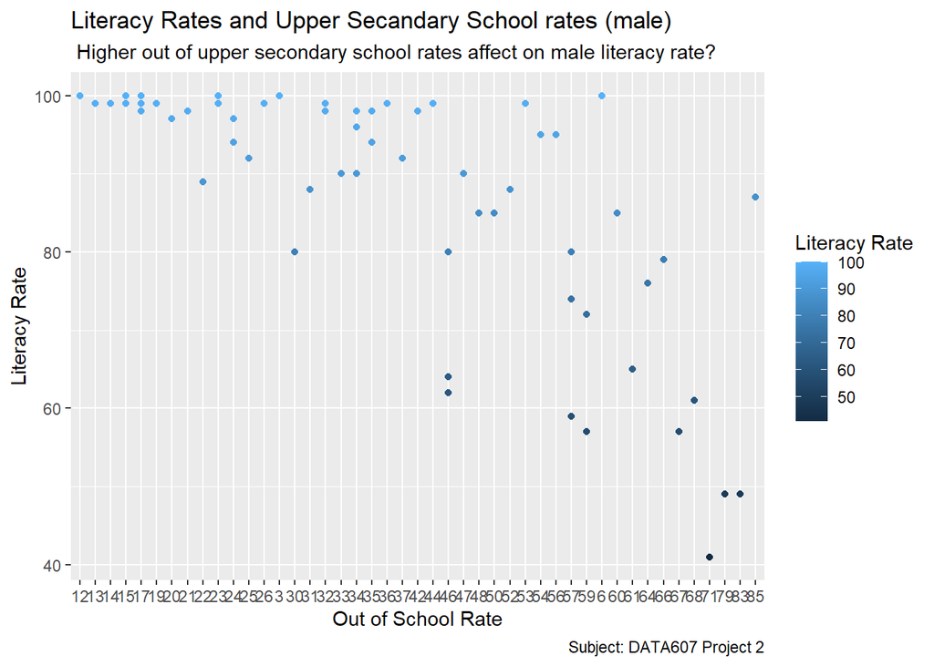